# Studying the effect of sequencing error

## The ideal COI estimate

Our approach to running our data was as follows: for all high COI samples (as defined in the code above), we would determine the COI for a series of different sequencing errors. In particular the sequencing error would range from `0` to `0.2` in increments of `0.01`. Given this set of COI estimations, we would then try to find the “ideal” COI estimate.

For instance, let us assume we have an output that looks like the following.

```
#> # A tibble: 5 × 6
#>   name     dis_var dis_freq   cont_var cont_freq  file
#>   <chr>      <dbl> <list>        <dbl> <list>     <chr>
#> 1 PD1143-C       1 <dbl [21]>     1.06 <dbl [21]> cat_region_7_vcf_0
#> 2 PD1422-C       1 <dbl [21]>     1.04 <dbl [21]> cat_region_7_vcf_0
#> 3 PD1000-C       1 <dbl [21]>     1.03 <dbl [21]> cat_region_7_vcf_0
#> 4 PD0472-C       1 <dbl [21]>     1.06 <dbl [21]> cat_region_7_vcf_0
#> 5 PD1382-C       1 <dbl [21]>     1.03 <dbl [21]> cat_region_7_vcf_0
```

In order to understand the trend in COI estimation, we can actually plot the data.

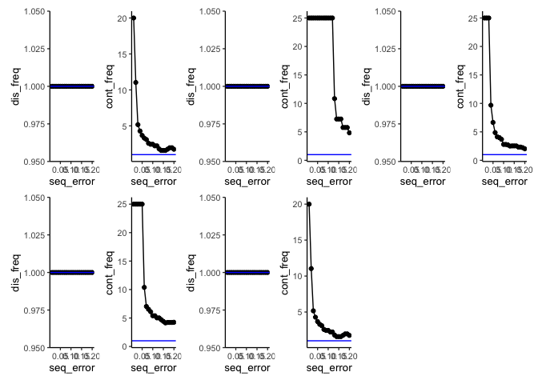

```r
plot_list <- purrr::map(
  seq_len(nrow(example)),
  function(x) {
    sample <- example %>%
      dplyr::slice_sample() %>%
      dplyr::select(name, dis_freq, cont_freq, dis_var)

    plot_error(sample, dis_freq) | plot_error(sample, cont_freq)
  }
)

wrap_plots(plot_list)
```

Interestingly, we can see that at a certain point, the COI estimation seems to flatten out. One strategy for finding the “ideal” COI estimate then would be to identify where the estimation flattens out.

To do so, we can write a simple function that looks for a series of $n$ points that are all close to one another.

```r
find_coi <- function(vector, cluster_size, threshold) {
  length_seq <- length(seq(0, 0.2, 0.01))
  found_coi <- FALSE

  # Start at a seq_error of 0.05 or 5%
  for (i in seq(6, length_seq - cluster_size)) {
    cluster <- vector[i:(i + cluster_size)]
    min <- min(cluster)
    max <- max(cluster)

    if (((max - min) <= threshold) & !found_coi) {
      found_coi <- TRUE
      coi <- mean(cluster)
      break
    }
  }

  if (found_coi) coi else 1
}
```

Applying our function to our example data:

```r
example %>%
  dplyr::rowwise() %>%
  dplyr::mutate(
    dis_var = unlist(dis_var),
    dis_freq = find_coi(dis_freq, 5, 0.5),
    .after = dis_var
  ) %>%
  dplyr::mutate(
    cont_var = unlist(cont_var),
    cont_freq = find_coi(cont_freq, 5, 0.5),
    .after = cont_var
  )
```

```
#> # A tibble: 5 × 6
#> # Rowwise:
#>   name     dis_var dis_freq cont_var cont_freq file
#>   <chr>      <dbl>    <dbl>    <dbl>     <dbl> <chr>
#> 1 PD1143-C       1        1     1.06      2.64 cat_region_7_vcf_0
#> 2 PD1422-C       1        1     1.04     25    cat_region_7_vcf_0
#> 3 PD1000-C       1        1     1.03      4.25 cat_region_7_vcf_0
#> 4 PD0472-C       1        1     1.06      2.09 cat_region_7_vcf_0
#> 5 PD1382-C       1        1     1.03      1.71 cat_region_7_vcf_0
```

Applying our ideal COI estimate to the samples with the highest COI estimates yielding improvement in our results. However, there were still several samples that had a COI estimation that was larger than anticipated. In the end, we decided to apply the ideal COI estimate strategy to all the samples in the Pf6 dataset. This resulted in our final Pf6 predictions.

```r
readRDS(here::here("archive", "vary-seq-error", "freq_variation.rds"))
```

[output not shown]